# Practical 2: Assessing Primary School Coverage

# Step 5: Identifying Population Coverage Target with Zonal Statistics

Idea: find outliers in population per primary school to set a target.

## Using Zonal statistics

*Zonal statistic*: summmary statistics of raster values at polygon level.

> The Zonal statistic function requires more time than we have! Let’s load the precalculation.

```r
#zon.stat<-extract(population, voronoi, df=TRUE, fun=sum,na.rm=TRUE)
#pop_per_voronoi <- zon.stat
pop_per_voronoi <- readRDS("data/pop_per_voronoi")
datatable(head(pop_per_voronoi))
```

|  | ID | lagos_pop_5_9 |
| --- | --- | --- |
| 1 | 1 | 6987.67620763183 |
| 2 | 2 | 13355.8587593138 |
| 3 | 3 | 12758.9905673042 |
| 4 | 4 | 1192.45427417755 |
| 5 | 5 | 3159.67615973949 |
| 6 | 6 | 14768.7685253695 |

## Setting a target

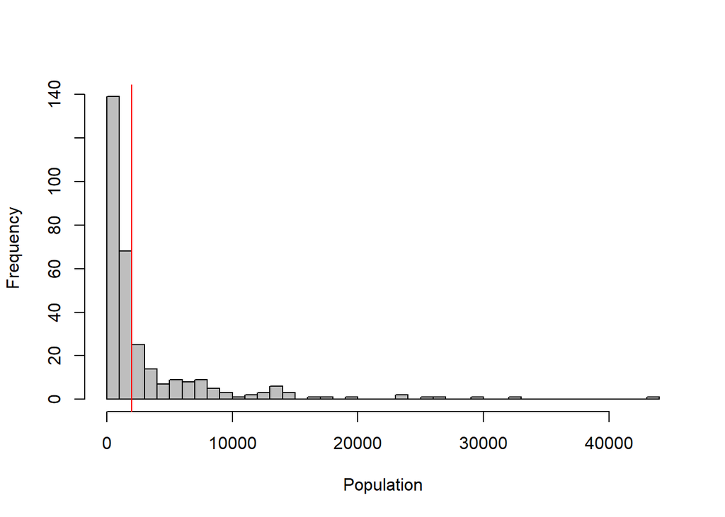

```r
hist(pop_per_voronoi$lagos_pop_5_9,
  breaks = 50,
  main = "",
  xlab = "Population",
  col = "grey"
)
abline(v = 2000, col = "red")
```

# Step 6: Identifying areas above target

We are subsetting the data to only include those voronois above the ‘target’ that can be seen in orange. These would be recommended for further intervention, such as the expansion of existing schools or placement of new school locations.

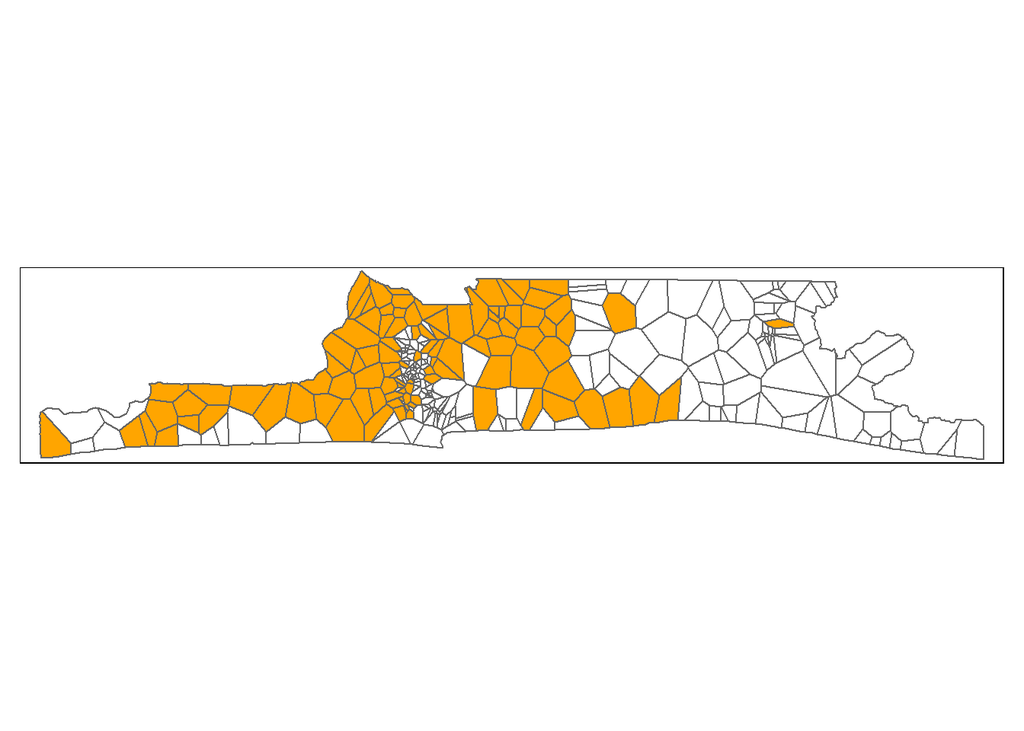

```r
voronoi <- voronoi %>% left_join(pop_per_voronoi, by = c("id" = "ID"))

above_target <- voronoi %>% filter(lagos_pop_5_9 > 2000)

tmap_mode("plot")
tm_shape(voronoi) +
  tm_borders() +
  tm_fill(col = "white") +
  tm_shape(above_target) +
  tm_borders() +
  tm_fill(col = "orange")
```

Project licence: GNU Affero General Public License v3.0